# Data Description:

## Label encoding for ordinal Catagorical variables

```python
# So considering default, housing, loan and Target as ordinal
# Label encoding for ordinal Catagorical  variables
from sklearn.preprocessing import LabelEncoder
df_encoded= df.copy(deep=True)
df_encoded.loc[:,['default','housing','loan','Target']]=df_encoded.loc[:,['default','housing','loan','Target']].apply(LabelEncoder().fit_transform)
```

Let's try to make more specific recommendations: Find out account balance, which marketing campaign should focus on:

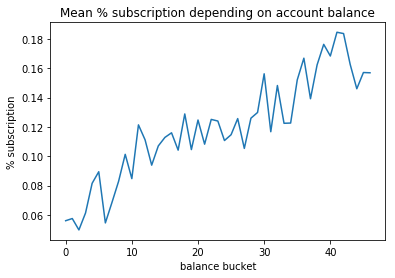

```python
#introduce new column 'balance_buckets'
df_encoded['balance_buckets'] = pd.qcut(df_encoded['balance'], 50, labels=False, duplicates = 'drop')

#group by 'balance_buckets' and find average campaign outcome per balance bucket
mean_deposit = df_encoded.groupby(['balance_buckets'])['Target'].mean()

#plot
plt.plot(mean_deposit.index, mean_deposit.values)
plt.title('Mean % subscription depending on account balance')
plt.xlabel('balance bucket')
plt.ylabel('% subscription')
plt.show()
```

```python
df_encoded[df_encoded['balance_buckets'] == 35]['balance'].min()
```

```
1509
```

So Bank should concentrate on Clients with balance more than 1500 euro

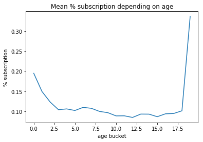

```python
#introduce new column 'age_buckets' to  ''
df_encoded['age_buckets'] = pd.qcut(df_encoded['age'], 20, labels=False, duplicates = 'drop')

#group by 'balance_buckets' and find average campaign outcome per balance bucket
mean_age = df_encoded.groupby(['age_buckets'])['Target'].mean()

#plot
plt.plot(mean_age.index, mean_age.values)
plt.title('Mean % subscription depending on age')
plt.xlabel('age bucket')
plt.ylabel('% subscription')
plt.show()
```

```python
df_encoded[df_encoded['age_buckets'] == 3]['age'].max()
```

```
32
```

```python
df_encoded[df_encoded['age_buckets'] == 18]['age'].min()
```

```
57
```

Bank should concentrate on client with age less than 32 and greater than 57 for term deposit

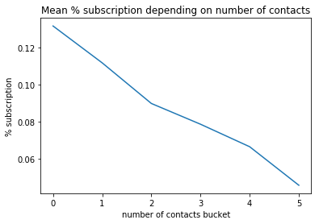

```python
#introduce new column 'age_buckets' to  ''
df_encoded['campaign_buckets'] = pd.qcut(df_encoded['campaign'], 20, labels=False, duplicates = 'drop')

#group by 'balance_buckets' and find average campaign outcome per balance bucket
mean_campaign = df_encoded.groupby(['campaign_buckets'])['Target'].mean()

#plot average campaign outcome per bucket
plt.plot(mean_campaign.index, mean_campaign.values)
plt.title('Mean % subscription depending on number of contacts')
plt.xlabel('number of contacts bucket')
plt.ylabel('% subscription')
plt.show()
```

```python
df_encoded[df_encoded['campaign_buckets'] == 1]['campaign'].min()
```

```
3
```

From the plot above we see that average subscription rate is below 10% if the number of contacts during the campaign exceeds 3. So Clients should not be contacted more than 3

## Correlation with heat map

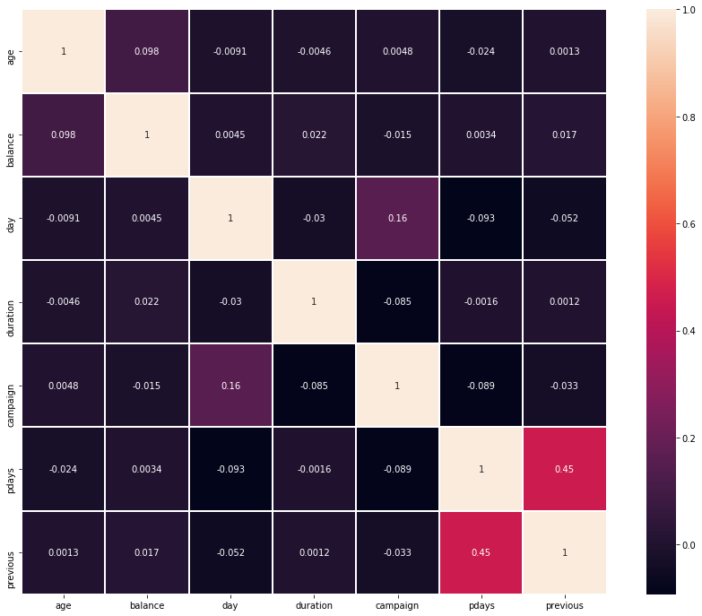

```python
#Pearson Correlation for Continuous Variable
corr = df.corr()
plt.figure(figsize = (16,12))
sns.heatmap(corr,linewidths=1,square=True, annot=True)
```

## Checking of Data Distribution for Target Column

```python
df.groupby(["Target"]).count()
# There is data imbalance. Customer who avail for Term Deposit are just approx 10% of total data.
```

| Target | age | job | marital | education | default | balance | housing | loan | contact | day | month | duration | campaign | pdays | previous | poutcome |
| --- | --- | --- | --- | --- | --- | --- | --- | --- | --- | --- | --- | --- | --- | --- | --- | --- |
| no | 39922 | 39922 | 39922 | 39922 | 39922 | 39922 | 39922 | 39922 | 39922 | 39922 | 39922 | 39922 | 39922 | 39922 | 39922 | 39922 |
| yes | 5289 | 5289 | 5289 | 5289 | 5289 | 5289 | 5289 | 5289 | 5289 | 5289 | 5289 | 5289 | 5289 | 5289 | 5289 | 5289 |

### Customer who is going for Term deposits vs not doing deposits are approx 1:7.5 .Though its natural. However, for modelling, There is data imbalance. So we will run algorithm with given data and using upsampling as well

# USING UPSAMLING FOR DATA IMBALANCE

```python
from sklearn.utils import resample
df_majority=df_encoded[df_encoded["Target"]==0]
df_minority=df_encoded[df_encoded["Target"]==1]
df_minority_upsampled=resample(df_minority,replace=True,n_samples=39922,random_state=123)
df_upsampled=pd.concat([df_minority_upsampled,df_majority])
```

```python
print(df_upsampled["Target"].value_counts())
```

```
1    39922
0    39922
Name: Target, dtype: int64
```

```python
X = df_encoded.drop(['Target','duration'], axis=1)
y = df_encoded["Target"]

X_upsampled = df_upsampled.drop(['Target','duration'], axis=1)
y_upsampled = df_upsampled["Target"]
```

## Dropping 'duration' column is necessary as this attribute highly affects the output Target.

```python
X.info()
```

[output not shown]

### Convert non ordinal categorical column into numeric ones

### Check the categories which are non numerical

```python
categoryList = list(X.select_dtypes(include=['object']).columns)
print(categoryList)
```

```
['job', 'marital', 'education', 'contact', 'month', 'poutcome']
```

```python
## Create dummy variables for non numerical categorical variables
dummies = pd.get_dummies(X[categoryList], prefix= categoryList)
print(dummies.head())
```

```
   job_admin.  job_blue-collar  job_entrepreneur  job_housemaid  \
0           0                0                 0              0
1           0                0                 0              0
2           0                0                 1              0
3           0                1                 0              0
4           0                0                 0              0

   job_management  job_retired  job_self-employed  job_services  job_student  \
0               1            0                  0             0            0
1               0            0                  0             0            0
2               0            0                  0             0            0
3               0            0                  0             0            0
4               0            0                  0             0            0

   job_technician  ...  month_jun  month_mar  month_may  month_nov  month_oct  \
```

[output cut: 21 more lines]

```python
## Drop Actual Non numerical categorical columns after creating dummies
X.drop(categoryList, axis=1, inplace = True)
print(X.head())
```

```
   age  default  balance  housing  loan  day  campaign  pdays  previous  \
0   58        0     2143        1     0    5         1     -1         0
1   44        0       29        1     0    5         1     -1         0
2   33        0        2        1     1    5         1     -1         0
3   47        0     1506        1     0    5         1     -1         0
4   33        0        1        0     0    5         1     -1         0

   balance_buckets  age_buckets  campaign_buckets
0               38           18                 0
1                7           12                 0
2                5            4                 0
3               34           14                 0
4                5            4                 0
```

X.info()

```python
## Concating encoded categorical columns with data frame (without actual columns)
X=pd.concat([X,dummies], axis =1 )
print(X.head())
```

```
   age  default  balance  housing  loan  day  campaign  pdays  previous  \
0   58        0     2143        1     0    5         1     -1         0
1   44        0       29        1     0    5         1     -1         0
2   33        0        2        1     1    5         1     -1         0
3   47        0     1506        1     0    5         1     -1         0
4   33        0        1        0     0    5         1     -1         0

   balance_buckets  ...  month_jun  month_mar  month_may  month_nov  \
0               38  ...          0          0          1          0
1                7  ...          0          0          1          0
2                5  ...          0          0          1          0
3               34  ...          0          0          1          0
4                5  ...          0          0          1          0

   month_oct  month_sep  poutcome_failure  poutcome_other  poutcome_success  \
0          0          0                 0               0                 0
1          0          0                 0               0                 0
2          0          0                 0               0                 0
3          0          0                 0               0                 0
4          0          0                 0               0                 0

   poutcome_unknown
0                 1
1                 1
2                 1
3                 1
4                 1

[5 rows x 50 columns]
```

```python
# Doing the same steps for upsampled

categoryList = list(X_upsampled.select_dtypes(include=['object']).columns)
print(categoryList)
print("\n")

# Create dummy variables (upsampled data) for non numerical categorical variables
dummies = pd.get_dummies(X_upsampled[categoryList], prefix= categoryList)
print(dummies.head())
print("\n")

# Drop Non numerical categorical columns
X_upsampled.drop(categoryList, axis=1, inplace = True)
print(X_upsampled.head())
print("\n")


X_upsampled=pd.concat([X_upsampled,dummies], axis =1 ) ## added encoded categorical columns
```

```
['job', 'marital', 'education', 'contact', 'month', 'poutcome']


       job_admin.  job_blue-collar  job_entrepreneur  job_housemaid  \
41902           0                0                 0              0
41549           0                0                 0              0
26997           0                0                 0              0
42861           0                0                 0              0
45073           0                0                 0              0

       job_management  job_retired  job_self-employed  job_services  \
41902               0            1                  0             0
41549               0            0                  0             0
26997               1            0                  0             0
42861               1            0                  0             0
45073               1            0                  0             0

       job_student  job_technician  ...  month_jun  month_mar  month_may  \
41902            0               0  ...          0          0          0
41549            0               1  ...          0          0          0
26997            0               0  ...          0          0          0
42861            0               0  ...          0          0          0
45073            0               0  ...          0          0          0

       month_nov  month_oct  month_sep  poutcome_failure  poutcome_other  \
41902          0          1          0                 0               0
41549          0          0          1                 0               0
26997          1          0          0                 1               0
42861          0          0          0                 0               0
45073          0          1          0                 0               0

       poutcome_success  poutcome_unknown
41902                 0                 1
41549                 0                 1
26997                 0                 0
42861                 1                 0
45073                 1                 0

[5 rows x 38 columns]


       age  default  balance  housing  loan  day  campaign  pdays  previous  \
41902   72        0     1388        0     0   20         1     -1         0
41549   42        0     3082        0     0   11         1     -1         0
26997   59        0     7049        0     0   21         1    163         2
42861   37        0      238        0     0    3         1     92         1
45073   37        0      203        0     0   21         1     90         5

       balance_buckets  age_buckets  campaign_buckets
41902               34           19                 0
41549               40           11                 0
26997               45           18                 0
42861               15            8                 0
45073               14            8                 0
```

```python
print(X.head())
print("\n")
print(X_upsampled.head())
```

```
   age  default  balance  housing  loan  day  campaign  pdays  previous  \
0   58        0     2143        1     0    5         1     -1         0
1   44        0       29        1     0    5         1     -1         0
2   33        0        2        1     1    5         1     -1         0
3   47        0     1506        1     0    5         1     -1         0
4   33        0        1        0     0    5         1     -1         0

   balance_buckets  ...  month_jun  month_mar  month_may  month_nov  \
0               38  ...          0          0          1          0
1                7  ...          0          0          1          0
2                5  ...          0          0          1          0
3               34  ...          0          0          1          0
4                5  ...          0          0          1          0

   month_oct  month_sep  poutcome_failure  poutcome_other  poutcome_success  \
```

[output cut: 45 more lines]

```python
X.info()
```

```
<class 'pandas.core.frame.DataFrame'>
RangeIndex: 45211 entries, 0 to 45210
Data columns (total 50 columns):
age                    45211 non-null int64
default                45211 non-null int32
balance                45211 non-null int64
housing                45211 non-null int32
loan                   45211 non-null int32
day                    45211 non-null int64
campaign               45211 non-null int64
pdays                  45211 non-null int64
previous               45211 non-null int64
balance_buckets        45211 non-null int64
age_buckets            45211 non-null int64
campaign_buckets       45211 non-null int64
job_admin.             45211 non-null uint8
job_blue-collar        45211 non-null uint8
job_entrepreneur       45211 non-null uint8
job_housemaid          45211 non-null uint8
job_management         45211 non-null uint8
job_retired            45211 non-null uint8
job_self-employed      45211 non-null uint8
job_services           45211 non-null uint8
job_student            45211 non-null uint8
job_technician         45211 non-null uint8
job_unemployed         45211 non-null uint8
job_unknown            45211 non-null uint8
marital_divorced       45211 non-null uint8
marital_married        45211 non-null uint8
marital_single         45211 non-null uint8
education_primary      45211 non-null uint8
education_secondary    45211 non-null uint8
education_tertiary     45211 non-null uint8
education_unknown      45211 non-null uint8
contact_cellular       45211 non-null uint8
contact_telephone      45211 non-null uint8
contact_unknown        45211 non-null uint8
month_apr              45211 non-null uint8
month_aug              45211 non-null uint8
month_dec              45211 non-null uint8
month_feb              45211 non-null uint8
month_jan              45211 non-null uint8
month_jul              45211 non-null uint8
month_jun              45211 non-null uint8
month_mar              45211 non-null uint8
month_may              45211 non-null uint8
month_nov              45211 non-null uint8
month_oct              45211 non-null uint8
month_sep              45211 non-null uint8
poutcome_failure       45211 non-null uint8
poutcome_other         45211 non-null uint8
poutcome_success       45211 non-null uint8
poutcome_unknown       45211 non-null uint8
dtypes: int32(3), int64(9), uint8(38)
memory usage: 5.3 MB
```

## Data processing for Negative values

- There are Negative values in balance and pdays columns. Negative values in balance is possible. As bank have provision of overdraft, In that case bank balance can be in negative in account
- Negative values in pdays represent Client was not contacted in previous contact. No have negative will differciate it from customer contacted . So we are not changing it.

## Data processing for outliers values

- Outliers are being treated by feature scaling of data using minmax scaler(below)

## Feature Scaling of Data

```python
from sklearn import preprocessing
min_max_scaler=preprocessing.MinMaxScaler()
X = min_max_scaler.fit_transform(X)
X= pd.DataFrame(X)
X_upsampled = min_max_scaler.fit_transform(X_upsampled)
X_upsampled= pd.DataFrame(X_upsampled)

# To take care of Outliers using MinMax Scaler
```

# Splitting the dataset into the Training set and Test set

```python
from sklearn.model_selection import train_test_split
X_train, X_test, y_train, y_test = train_test_split(X, y, test_size = 0.3, random_state = 0)
X_train, X_test_upsampled, y_train, y_test_upsampled = train_test_split(X_upsampled, y_upsampled, test_size = 0.3, random_state = 0)
```

## Standard Classification Algorithms

# KNN

## Choosing a K Value

Find out the point where the error is least

```python
from sklearn.neighbors import KNeighborsClassifier
error_rate = []

# Will take some time
for i in range(1,20):

    knn = KNeighborsClassifier(n_neighbors=i)
    knn.fit(X_train,y_train)
    pred_i = knn.predict(X_test)
    error_rate.append(np.mean(pred_i != y_test))
```

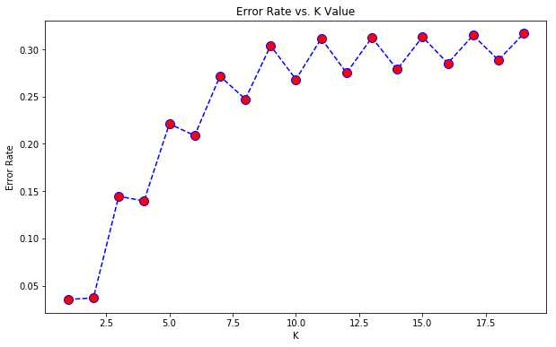

```python
plt.figure(figsize=(10,6))
plt.plot(range(1,20),error_rate,color='blue', linestyle='dashed', marker='o',
         markerfacecolor='red', markersize=10)
plt.title('Error Rate vs. K Value')
plt.xlabel('K')
plt.ylabel('Error Rate')
```

## As per error vs K plot, error is minimum, when K=1. So we are run model with K=1

```python
from sklearn.neighbors import KNeighborsClassifier
knn = KNeighborsClassifier(n_neighbors=1)
knn.fit(X_train,y_train)

pred_knn_us = knn.predict(X_test)

from sklearn.metrics import classification_report,confusion_matrix
knn_cm_us = confusion_matrix(y_test,pred_knn_us)
knn_cr_us= classification_report(y_test,pred_knn_us)

print(knn_cm_us)
print(knn_cr_us)
```

```
[[11496   473]
 [    7  1588]]
              precision    recall  f1-score   support

           0       1.00      0.96      0.98     11969
           1       0.77      1.00      0.87      1595

   micro avg       0.96      0.96      0.96     13564
   macro avg       0.88      0.98      0.92     13564
weighted avg       0.97      0.96      0.97     13564
```

```python
from sklearn.model_selection import cross_val_score

accuracies_knn= cross_val_score(estimator = knn, X = X_train, y = y_train, cv = 10)
accuracies_knn

accuracies_knn_us_mean=accuracies_knn.mean()
print("Mean Accuracy:KNN UPSAMPLE=",accuracies_knn_us_mean)

accuracies_knn_us_std=accuracies_knn.std()
print("Standard Deviation:KNN UPSAMPLE=",accuracies_knn_us_std)

mean_roc_auc_score_knn_us = cross_val_score(estimator = knn, X = X_train, y = y_train, scoring="roc_auc", cv = 10).mean()
std_roc_auc_score_knn_us = cross_val_score(estimator = knn, X = X_train, y = y_train, scoring="roc_auc", cv = 10).std()

print("Mean AUC ROC Score:KNN UPSAMPLE=",mean_roc_auc_score_knn_us)
print("Std Dev AUC ROC Score:KNN UPSAMPLE=",std_roc_auc_score_knn_us)
```

```
Mean Accuracy:KNN UPSAMPLE= 0.9246196460989102
Standard Deviation:KNN UPSAMPLE= 0.0028901657938192145
Mean AUC ROC Score:KNN UPSAMPLE= 0.9240769882150157
Std Dev AUC ROC Score:KNN UPSAMPLE= 0.002895335130383202
```